# Reproducible Research - Project 1

Scott K

8/2/2020

===============================================================================

### Loading and preprocessing the data

1. Load necessary libraries
2. Set file location
3. Read in the data
4. Tranform dates using as.Date()

```r
library(ggplot2)
library(dplyr)
file_data <- "activity.csv"

data <- read.csv(file_data, header = TRUE, stringsAsFactors = FALSE)
data$date <- as.Date(as.character(data$date), "%Y-%m-%d")
head(data)
```

```
##   steps       date interval
## 1    NA 2012-10-01        0
## 2    NA 2012-10-01        5
## 3    NA 2012-10-01       10
## 4    NA 2012-10-01       15
## 5    NA 2012-10-01       20
## 6    NA 2012-10-01       25
```

### What is the mean total number of steps taken per day?

1. Calculate the number of steps taken per day

```r
daily_data <- data %>%
        group_by(date) %>%
        summarize(daily_steps = sum(steps))
head(daily_data)
```

```
## # A tibble: 6 x 2
##   date       daily_steps
##   <date>           <int>
## 1 2012-10-01          NA
## 2 2012-10-02         126
## 3 2012-10-03       11352
## 4 2012-10-04       12116
## 5 2012-10-05       13294
## 6 2012-10-06       15420
```

2. Make a histogram of the total number of steps taken each day

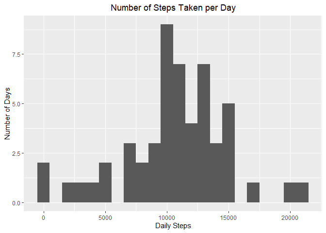

```r
ggplot(daily_data, aes(daily_steps)) +
        geom_histogram(na.rm = TRUE, binwidth = 1000) +
        labs(title = "Number of Steps Taken per Day") +
        xlab("Daily Steps") +
        ylab("Number of Days") +
        theme(plot.title = element_text(hjust = 0.5))
```

3. Calculate and report the mean and median of the total number of steps taken per day

```r
daily_data %>%
        summarize(daily_mean = mean(daily_steps, na.rm = TRUE),
                  daily_median = median(daily_steps, na.rm = TRUE))
```

```
## # A tibble: 1 x 2
##   daily_mean daily_median
##        <dbl>        <int>
## 1     10766.        10765
```

### What is the average daily activity pattern?

1. Make a time series plot (i.e. *type = “l”*) of the 5-minute interval (x-axis) and the average number of steps taken, averaged across all days (y-axis)
1. Calculate the number of steps taken per interval

```r
int_data <- data %>%
        na.omit() %>%
        group_by(interval) %>%
        summarize(int_steps = mean(steps))
head(int_data)
```

```
## # A tibble: 6 x 2
##   interval int_steps
##      <int>     <dbl>
## 1        0    1.72
## 2        5    0.340
## 3       10    0.132
## 4       15    0.151
## 5       20    0.0755
## 6       25    2.09
```

2. Create the time series plot

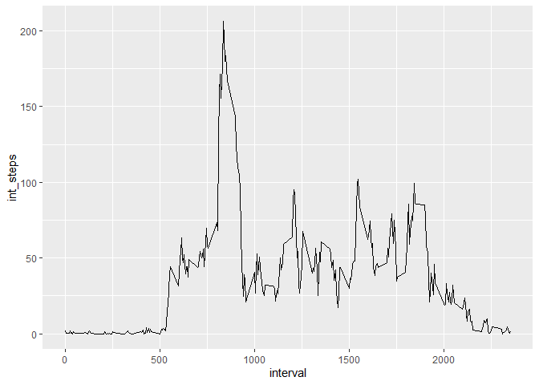

```r
ggplot(int_data, aes(interval, int_steps)) +
        geom_line()
```

2. Which 5-minute interval, on average across all the days in the dataset, contains the maximum number of steps?

```r
int_data %>%
        filter(int_steps == max(int_steps))
```

```
## # A tibble: 1 x 2
##   interval int_steps
##      <int>     <dbl>
## 1      835      206.
```

### Imputing missing values

1. Calculate and report the total number of missing values in the dataset.

```r
sapply(data, function(x) sum(is.na(x)))
```

```
##    steps     date interval
##     2304        0        0
```

2. Devise a strategy or filling in all of the missing values in the dataset.

   ```
    We will replace each missing value with the average value for that time
    interval in the dataset.
   ```

3. Create a new dataset that is equal to the original dataset but with the missing data filled in.

```r
data_noNA <- data

for (i in 1:nrow(data)){
        if(is.na(data$steps[i])) {
                data_noNA$steps[i] <-
                        int_data$int_steps[data_noNA$interval[i]
                                           == int_data$interval]
        }
}

sapply(data_noNA, function(x) sum(is.na(x)))
```

```
##    steps     date interval
##        0        0        0
```

4. Make a histogram of the total number of steps taken each day. (First, must calculate the steps taken each day, then graph)

```r
daily_data2 <- data_noNA %>%
        group_by(date) %>%
        summarize(daily_steps = sum(steps))
head(daily_data2)
```

```
## # A tibble: 6 x 2
##   date       daily_steps
##   <date>           <dbl>
## 1 2012-10-01      10766.
## 2 2012-10-02        126
## 3 2012-10-03      11352
## 4 2012-10-04      12116
## 5 2012-10-05      13294
## 6 2012-10-06      15420
```

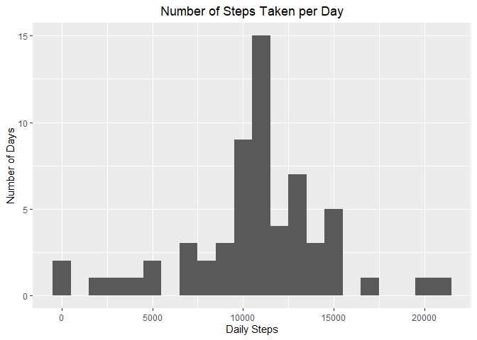

```r
ggplot(daily_data2, aes(daily_steps)) +
        geom_histogram(na.rm = TRUE, binwidth = 1000) +
        labs(title = "Number of Steps Taken per Day") +
        xlab("Daily Steps") +
        ylab("Number of Days") +
        theme(plot.title = element_text(hjust = 0.5))
```

4. (cont) Calculate the mean and median total number of steps taken per day.

```r
daily_data2 %>%
        summarize(daily_mean = mean(daily_steps, na.rm = TRUE),
                  daily_median = median(daily_steps, na.rm = TRUE))
```

```
## # A tibble: 1 x 2
##   daily_mean daily_median
##        <dbl>        <dbl>
## 1     10766.       10766.
```

### Are there differences in activity patterns between weekdays and weekends?

1. Create a new factor variable in the dataseet with two levels - “weekday” and “weekend” indicating whether a given date is a weekday or weekend day.

```r
data_noNA$day_week <- ifelse(weekdays(data_noNA$date) %in%
                            c("Saturday", "Sunday"), "weekend", "weekday")
data_noNA$day_week <- as.factor(data_noNA$day_week)

head(data_noNA)
```

```
##       steps       date interval day_week
## 1 1.7169811 2012-10-01        0  weekday
## 2 0.3396226 2012-10-01        5  weekday
## 3 0.1320755 2012-10-01       10  weekday
## 4 0.1509434 2012-10-01       15  weekday
## 5 0.0754717 2012-10-01       20  weekday
## 6 2.0943396 2012-10-01       25  weekday
```

2. Make a panel plot containing a time series plot of the 5-minute intervals and the average number of steps taken, averaged across all weekday days or weekend days. (First, must calculate the average steps per interval)

```r
int_data2 <- data_noNA %>%
        group_by(day_week, interval) %>%
        summarize(int_steps = mean(steps))
head(int_data2)
```

```
## # A tibble: 6 x 3
## # Groups:   day_week [1]
##   day_week interval int_steps
##   <fct>       <int>     <dbl>
## 1 weekday         0    2.25
## 2 weekday         5    0.445
## 3 weekday        10    0.173
## 4 weekday        15    0.198
## 5 weekday        20    0.0990
## 6 weekday        25    1.59
```

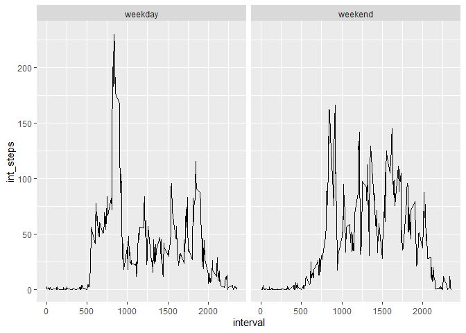

```r
ggplot(int_data2, aes(interval, int_steps)) +
        geom_line() +
        facet_grid(. ~ day_week)
```